# Análise da Geração, Consumo e Consumidores

# Consumo por Setores

Setor Industrial: O Motor do Consumo Historicamente, o setor industrial sempre foi o maior consumidor de energia elétrica no Brasil. Em 2020, ele representou aproximadamente 37% de todo o consumo energético do país. As indústrias de mineração, siderurgia e manufatura são particularmente intensivas em energia, especialmente no estado de Minas Gerais, onde as atividades de extração e processamento de metais são predominantes.

Além disso, o aumento da produção agrícola no Centro-Oeste e a expansão de indústrias ligadas ao agronegócio têm impulsionado o crescimento do consumo de energia nesse setor.

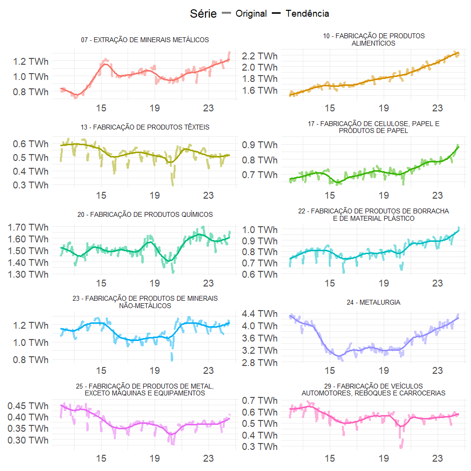

```r
setor %>%
  dplyr::summarise(Consumo = sum(Consumo),
                   .by = c(DataExcel, SetorIndustrial)) %>%
  dplyr::mutate(DataExcel = tsibble::yearmonth(DataExcel)) %>%
  tsibble::as_tsibble(index = DataExcel, key = SetorIndustrial) %>%
  fabletools::model(STL(Consumo)) %>%
  fabletools::components() %>%
  dplyr::mutate(DataExcel = as.Date(DataExcel)) %>%
  ggplot() +
  geom_line(aes(x = DataExcel,
                y = Consumo,
                color = SetorIndustrial,
                linetype = 'Original'),
            linewidth = 1.45,
            alpha = 0.5) +
  geom_line(aes(x = DataExcel,
                y = trend,
                color = SetorIndustrial,
                linetype = 'Tendência'),
            linewidth = 1.4) +
  labs(x = element_blank(),
       y = element_blank(),
       linetype = 'Série',
       color = 'Setor') +
  scale_x_date(date_breaks = '4 year',
               date_labels = '%y') +
  scale_y_continuous(labels = scales::number_format(suffix = ' TWh',
                                                    scale = 1/1e6)) +
  scale_linetype_manual(values = c('longdash', 'solid')) +
  scale_color_discrete(guide = 'none') +
  facet_wrap(~SetorIndustrial, scales = 'free',
             ncol = 2, labeller = label_wrap_gen(width = 40)) +
  theme_minimal() +
  theme(text = element_text(size = 18),
        strip.text = element_text(size = 10),
        legend.position = 'top')
```

# Setor Residencial: Crescimento e Urbanização

O setor residencial tem mostrado um crescimento constante, impulsionado pelo aumento da população urbana e pela maior utilização de aparelhos eletrônicos e eletrodomésticos. O número de consumidores conectados à rede elétrica aumentou significativamente nos últimos 10 anos, com mais de 80% das residências brasileiras equipadas com eletrodomésticos que demandam uma quantidade considerável de eletricidade, como ar-condicionado e eletrodomésticos de cozinha.

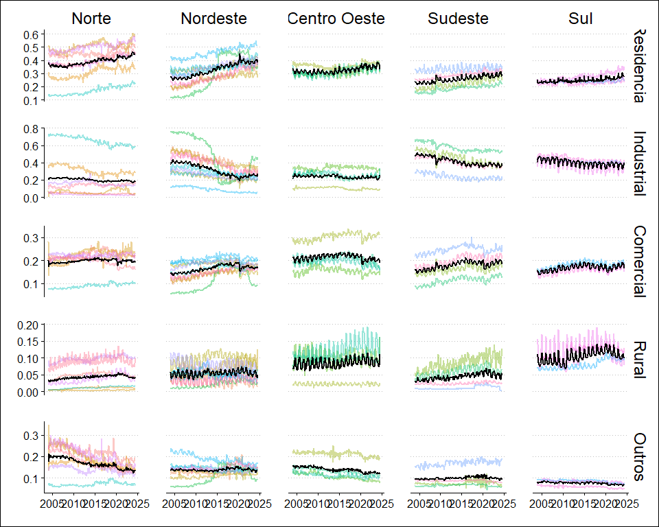

```r
# Pipeline para processar a média dos dados estado x classe e plotar
consumo %>%
  dplyr::summarise(Consumo = sum(Consumo),
                   .by = c(DataExcel, Classe, UF)) %>%
  tidyr::pivot_wider(names_from = Classe,
                     values_from = Consumo) %>%
  dplyr::rowwise() %>%
  dplyr::mutate(Total = sum(Comercial, Industrial, Outros, Residencial, Rural,
                            na.rm = TRUE),
                across(c(Comercial:Rural), ~ .x / Total)) %>%
  dplyr::ungroup() %>%
  tidyr::pivot_longer(cols = c(Comercial:Rural)) %>%
  dplyr::right_join(estados, by = c('UF' = 'abbrev_state')) %>%
  dplyr::mutate(name = factor(name,
                              levels = c("Residencial",
                                         "Industrial",
                                         "Comercial",
                                         "Rural",
                                         "Outros")),
                name_region = factor(name_region,
                                     levels = c("Norte",
                                                "Nordeste",
                                                "Centro Oeste",
                                                "Sudeste",
                                                "Sul"))) %>%
  dplyr::mutate(mean_value = mean(value,
                                  na.rm = TRUE),
                DataExcel = as.Date(DataExcel),
                .by = c(DataExcel, name_region, name)) %>%
  dplyr::select(DataExcel, UF, name, name_region, value, mean_value) %>%
  ggplot() +
  aes(x = DataExcel) +
  geom_line(aes(y = value,
                color = UF),
            size = 0.75,
            alpha = 0.4,
            show.legend = F) +
  geom_line(aes(y = mean_value),
            color = "black",
            size = 1,
            show.legend = F) +
  labs(x = '',
       y = '') +
  facet_grid(name ~ name_region,
             scales = 'free') +
  theme_clean() +
  theme(axis.text = element_text(size = 12),
        strip.text = element_text(size = 18),
        panel.spacing = unit(2, "lines"))
```

# Impactos das Energias Renováveis e Eficiência Energética

## A Transição para Energias Renováveis

Nos últimos anos, o Brasil tem dado passos significativos rumo a uma matriz energética mais limpa. Com um potencial natural abundante para a geração de energia solar e eólica, o país já é um dos líderes globais nesse setor. Em estados como Bahia e Ceará, a produção de energia eólica já responde por mais de 20% da oferta energética, e os investimentos em energia solar têm se multiplicado.

## Eficiência Energética: Um Desafio Pendente

Embora haja avanços em termos de geração de energia renovável, ainda existe um longo caminho a ser percorrido no que se refere à eficiência energética. O desperdício de energia nas redes de transmissão e o uso ineficiente em setores industriais e residenciais representam grandes desafios. O governo brasileiro já lançou alguns programas de incentivo à eficiência energética, mas sua implementação enfrenta obstáculos em regiões com menos infraestrutura.

# Projeções Futuras e Desafios

À medida que o Brasil continua a crescer, a demanda por energia elétrica deve seguir aumentando, especialmente nas regiões Norte e Nordeste, que estão experimentando um boom de infraestrutura. Estima-se que, até 2030, a demanda nacional por eletricidade crescerá cerca de 25%, colocando pressão sobre o sistema energético nacional.

Além disso, a dependência do Brasil em hidrelétricas, que representam mais de 60% da matriz energética, torna o país vulnerável a crises hídricas, como a que ocorreu em 2021. A diversificação da matriz energética, com um foco maior em fontes renováveis e melhorias na eficiência energética, será essencial para garantir a segurança energética no futuro.

# Conclusão

Este relatório revela que o consumo de energia no Brasil está profundamente ligado às dinâmicas econômicas e regionais do país. Enquanto o Sudeste continua sendo o principal consumidor de eletricidade, regiões como o Norte e Nordeste estão emergindo como novos polos de demanda e geração de energia, especialmente no campo das renováveis. O desafio para o futuro será equilibrar o crescimento da demanda com a necessidade de uma matriz energética sustentável e resiliente. Políticas públicas que incentivem a eficiência energética e a adoção de fontes limpas serão cruciais para o sucesso desse processo.

Allaire, JJ, Yihui Xie, Christophe Dervieux, Jonathan McPherson, Javier Luraschi, Kevin Ushey, Aron Atkins, et al. 2024. *rmarkdown: Dynamic Documents for r*. https://github.com/rstudio/rmarkdown.

Arnold, Jeffrey B. 2024. *ggthemes: Extra Themes, Scales and Geoms for “ggplot2”*. https://CRAN.R-project.org/package=ggthemes.

Cavalcante, Pedro, Daniel Herszenhut, and Rodrigo Dornelles. 2023. *basedosdados: “Base Dos Dados” r Client*. https://CRAN.R-project.org/package=basedosdados.

Hyndman, Rob. 2024. *Fpp3: Data for “Forecasting: Principles and Practice” (3rd Edition)*. https://CRAN.R-project.org/package=fpp3.

O’Hara-Wild, Mitchell, Rob Hyndman, and Earo Wang. 2024. *fabletools: Core Tools for Packages in the “fable” Framework*. https://CRAN.R-project.org/package=fabletools.

Pedersen, Thomas Lin. 2024. *patchwork: The Composer of Plots*. https://CRAN.R-project.org/package=patchwork.

Pedersen, Thomas Lin, and David Robinson. 2024. *gganimate: A Grammar of Animated Graphics*. https://CRAN.R-project.org/package=gganimate.

Pereira, Rafael H. M., and Caio Nogueira Goncalves. 2024. *geobr: Download Official Spatial Data Sets of Brazil*. https://CRAN.R-project.org/package=geobr.

Posit team. 2023. *RStudio: Integrated Development Environment for r*. Boston, MA: Posit Software, PBC. http://www.posit.co/.

Qiu, Yixuan. 2021. *prettydoc: Creating Pretty Documents from r Markdown*. https://CRAN.R-project.org/package=prettydoc.

R Core Team. 2024. *R: A Language and Environment for Statistical Computing*. Vienna, Austria: R Foundation for Statistical Computing. https://www.R-project.org/.

Sievert, Carson, Joe Cheng, and Garrick Aden-Buie. 2024. *bslib: Custom “Bootstrap” “Sass” Themes for “shiny” and “rmarkdown”*. https://CRAN.R-project.org/package=bslib.

Wang, Earo, Dianne Cook, and Rob J Hyndman. 2020. “A New Tidy Data Structure to Support Exploration and Modeling of Temporal Data.” *Journal of Computational and Graphical Statistics* 29 (3): 466–78. https://doi.org/10.1080/10618600.2019.1695624.

Wickham, Hadley, Mara Averick, Jennifer Bryan, Winston Chang, Lucy D’Agostino McGowan, Romain François, Garrett Grolemund, et al. 2019. “Welcome to the tidyverse.” *Journal of Open Source Software* 4 (43): 1686. https://doi.org/10.21105/joss.01686.

Wickham, Hadley, Thomas Lin Pedersen, and Dana Seidel. 2023. *scales: Scale Functions for Visualization*. https://CRAN.R-project.org/package=scales.

Xie, Yihui. 2014. “knitr: A Comprehensive Tool for Reproducible Research in R.” In *Implementing Reproducible Computational Research*, edited by Victoria Stodden, Friedrich Leisch, and Roger D. Peng. Chapman; Hall/CRC.

———. 2015. *Dynamic Documents with R and Knitr*. 2nd ed. Boca Raton, Florida: Chapman; Hall/CRC. https://yihui.org/knitr/.

———. 2024. *knitr: A General-Purpose Package for Dynamic Report Generation in r*. https://yihui.org/knitr/.

Xie, Yihui, J. J. Allaire, and Garrett Grolemund. 2018. *R Markdown: The Definitive Guide*. Boca Raton, Florida: Chapman; Hall/CRC. https://bookdown.org/yihui/rmarkdown.

Xie, Yihui, Christophe Dervieux, and Emily Riederer. 2020. *R Markdown Cookbook*. Boca Raton, Florida: Chapman; Hall/CRC. https://bookdown.org/yihui/rmarkdown-cookbook.

Zhu, Hao. 2024. *kableExtra: Construct Complex Table with “kable” and Pipe Syntax*. https://CRAN.R-project.org/package=kableExtra.